# Informe Pisa

Carlos Rodríguez-Viña Martínez

9/11/2020

Los modelos GAM permiten obtener ajustes no lineales empleando múltiples predictores. Son el resultado de extender un modelo lineal múltiple permitiendo que cada elemento del modelo sea una función no lineal de un predictor y manteniendo la aditividad. Son por lo tanto una combinación lineal de funciones no lineales.

El resultado es un modelo aditivo en el que se calcula una función no lineal fj separada para cada predictor Xj y luego se suman todas sus contribuciones.

Que los modelos GAM sean aditivos permite analizar la influencia de cada predictor sobre la variable respuesta de forma individual, algo muy útil a la hora de hacer inferencia

Procedemos a cargar las librerías que vamos a utilizar

Lo primero que vamos a realizar es cargar el dataset con el que vamos a trabajar y vamos a proceder a dar un nombre a este data set

Una vez que hemos revisado el dataset, observamos que existen varios valores dentro del dataframe con valores NA, es por ello que vamos a susitutir los valores NA por la media de cada variable

Observarmos cual es la linealidad de nuestras variables con respecto de Y.

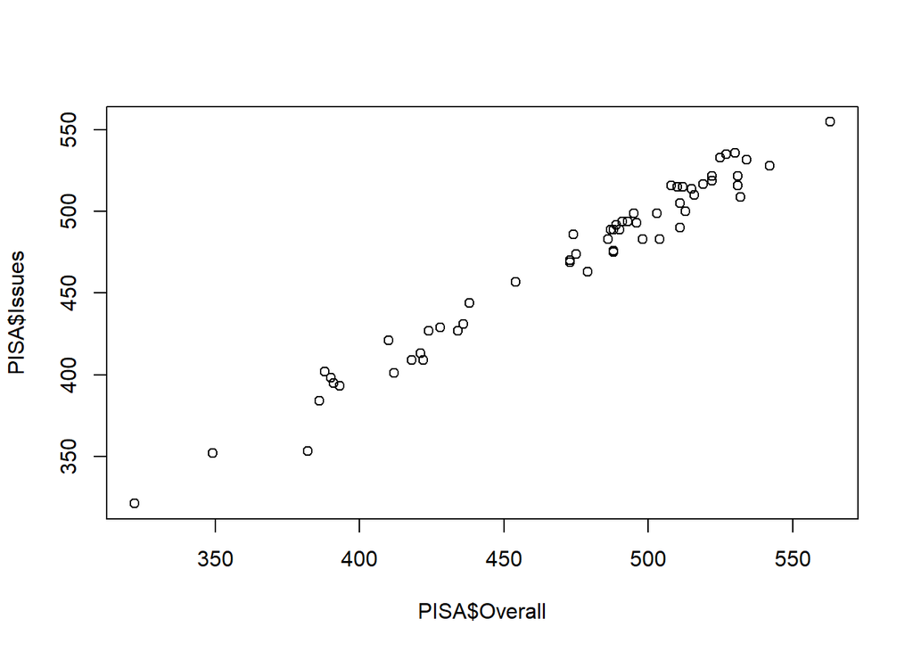

```r
plot(PISA$Overall, PISA$Issues)
```

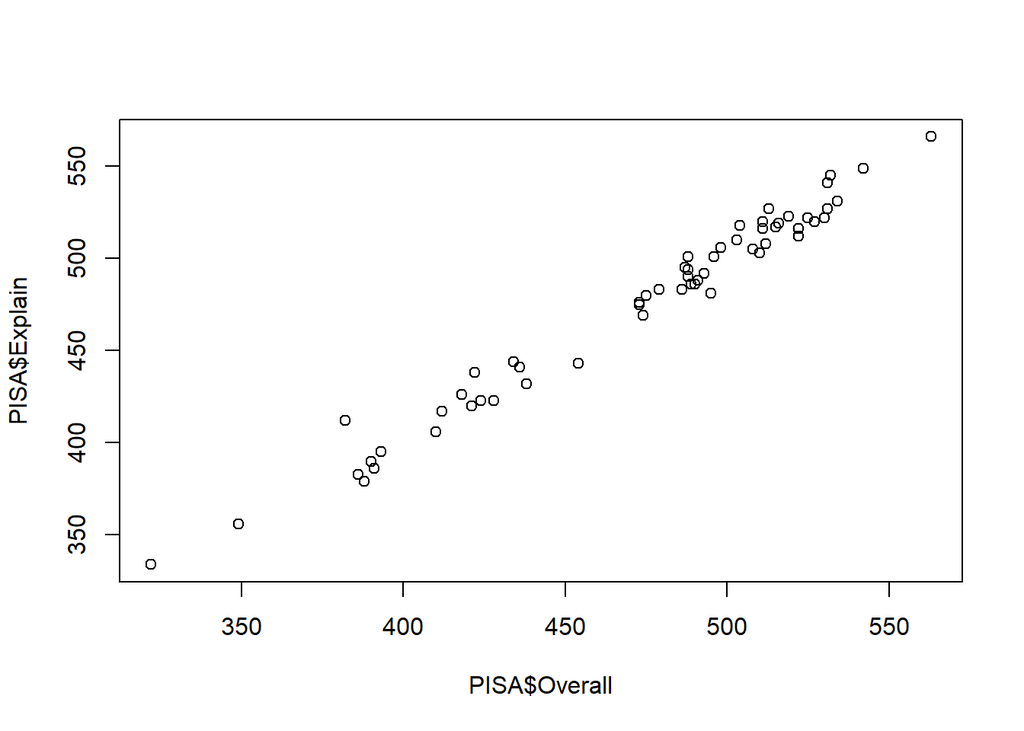

```r
plot(PISA$Overall, PISA$Explain)
```

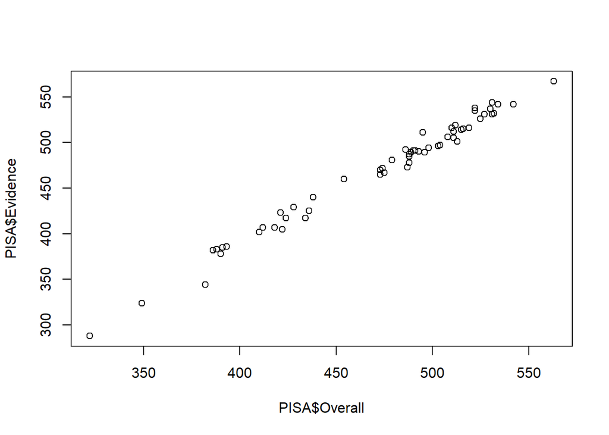

```r
plot(PISA$Overall, PISA$Evidence)
```

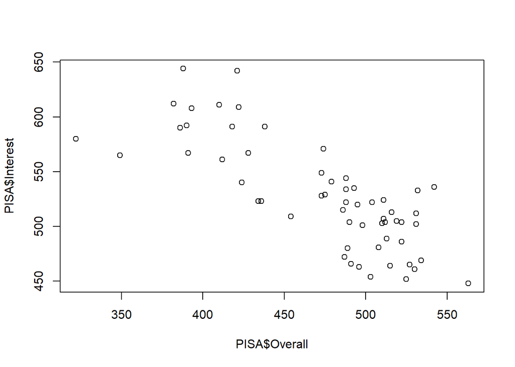

```r
plot(PISA$Overall, PISA$Interest)
```

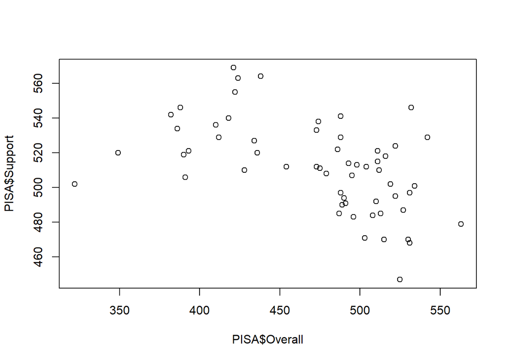

```r
plot(PISA$Overall, PISA$Support)
```

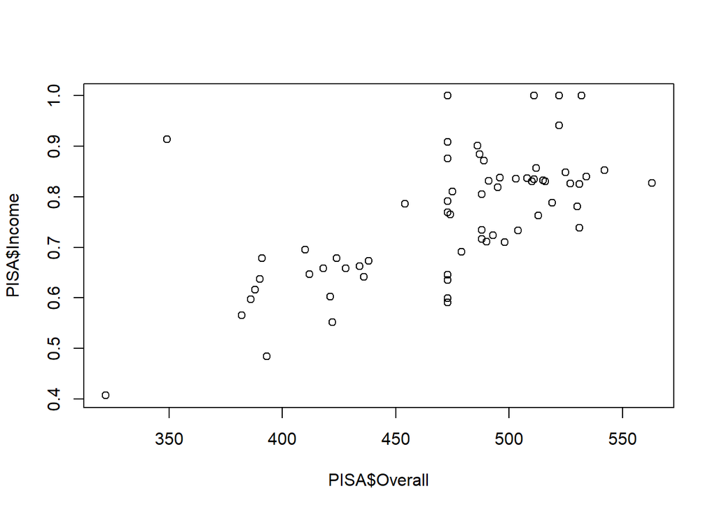

```r
plot(PISA$Overall, PISA$Income)
```

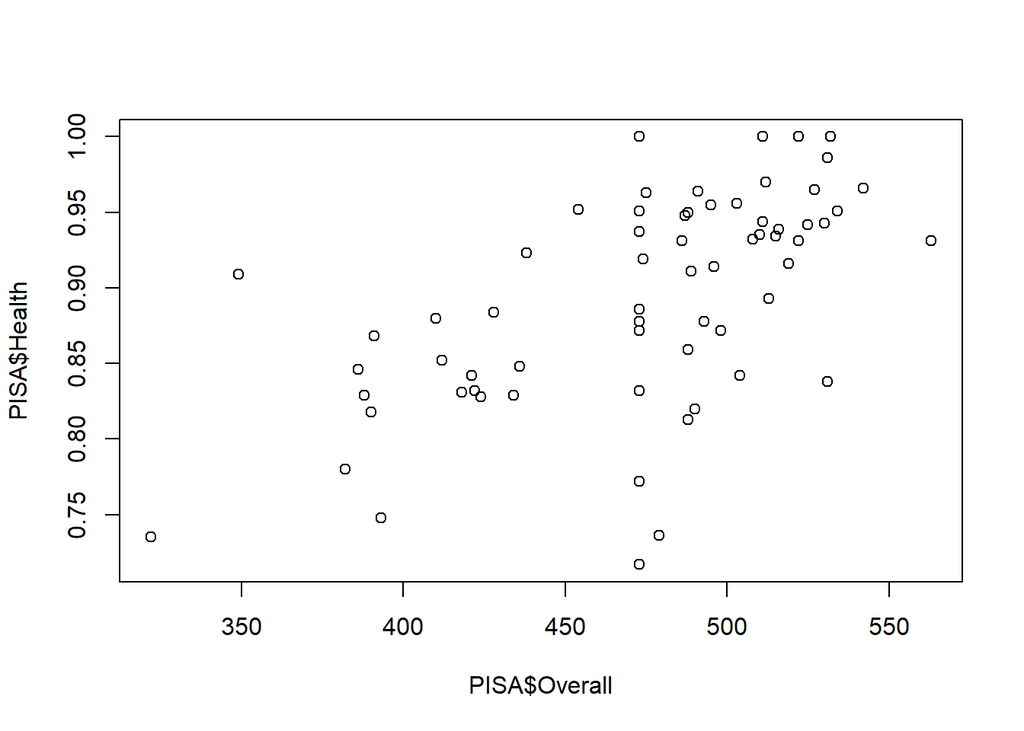

```r
plot(PISA$Overall, PISA$Health)
```

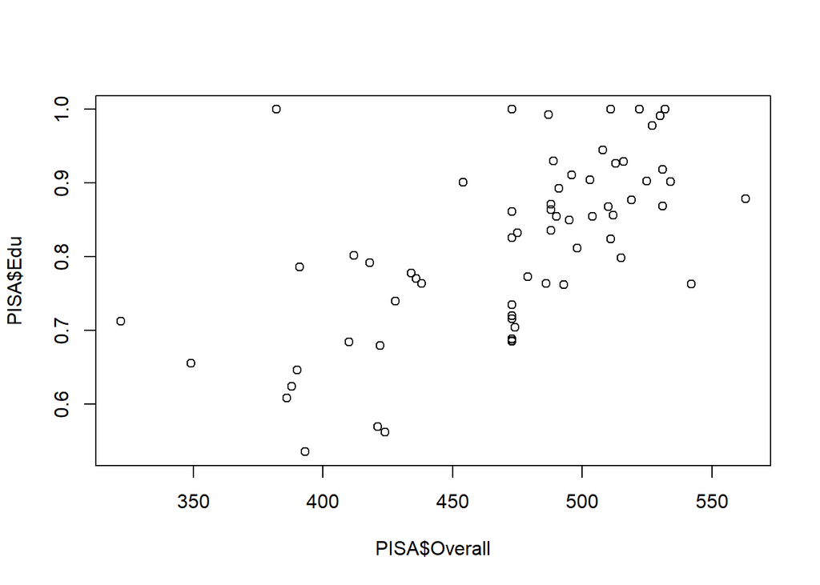

```r
plot(PISA$Overall, PISA$Edu)
```

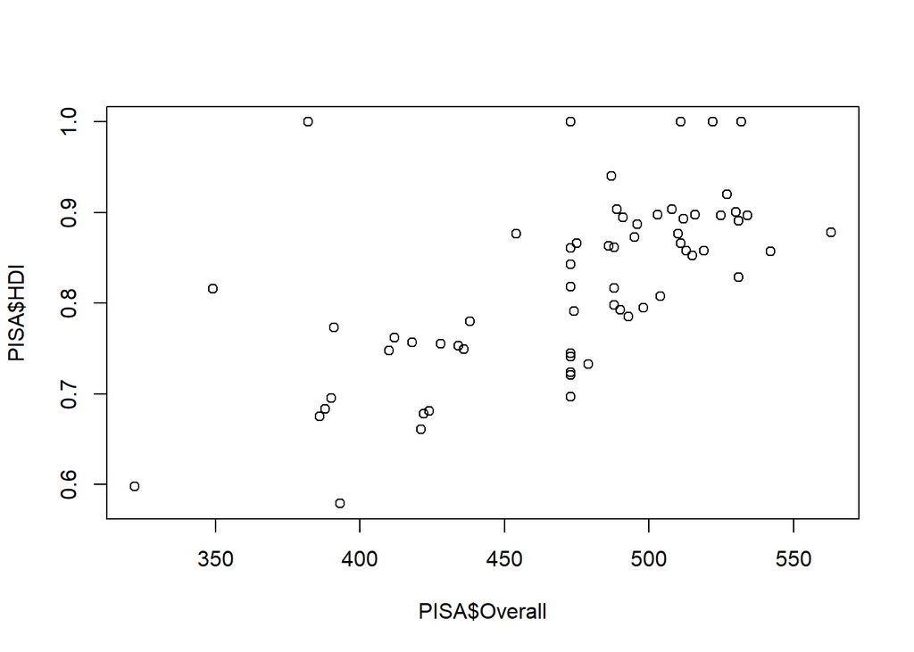

```r
plot(PISA$Overall, PISA$HDI)
```

Observamos que las variables Issues, Explain y Evidence mantienen una relación lineal con respecto de la variable Overall, por lo que no será necesario realizar ningún tipo de smooth a dicha variable.

# Modelo GAM

### Grados de Libertad

Primero vamos a obtenr los grados de libertad de cada una de las varibales, de tal manera que cuando proceda a realizar suavización de las variables conozca cuales son los K puntos de cada variable. Para ello vamos a realizar la validación cruzada de cada variable.

```r
smooth.spline(x = PISA$Interest, y = PISA$Overall, cv = TRUE) # 4.74
```

```
## Call:
## smooth.spline(x = PISA$Interest, y = PISA$Overall, cv = TRUE)
##
## Smoothing Parameter  spar= 0.9316597  lambda= 0.004695346 (13 iterations)
## Equivalent Degrees of Freedom (Df): 4.742052
## Penalized Criterion (RSS): 49583.01
## PRESS(l.o.o. CV): 917.079
```

```r
smooth.spline(x = PISA$Income, y = PISA$Overall, cv = TRUE) # 9.4
```

```
## Call:
## smooth.spline(x = PISA$Income, y = PISA$Overall, cv = TRUE)
##
## Smoothing Parameter  spar= 0.8489822  lambda= 0.0001401717 (18 iterations)
## Equivalent Degrees of Freedom (Df): 9.404201
## Penalized Criterion (RSS): 52258.63
## PRESS(l.o.o. CV): 1229.573
```

```r
smooth.spline(x = PISA$Support, y = PISA$Overall, cv = TRUE) # 2.00
```

```
## Call:
## smooth.spline(x = PISA$Support, y = PISA$Overall, cv = TRUE)
##
## Smoothing Parameter  spar= 1.499956  lambda= 142.9515 (29 iterations)
## Equivalent Degrees of Freedom (Df): 2.000712
## Penalized Criterion (RSS): 68340.47
## PRESS(l.o.o. CV): 1996.122
```

```r
smooth.spline(x = PISA$Health, y = PISA$Overall, cv = TRUE) # 2
```

```
## Call:
## smooth.spline(x = PISA$Health, y = PISA$Overall, cv = TRUE)
##
## Smoothing Parameter  spar= 1.499939  lambda= 33.28087 (26 iterations)
## Equivalent Degrees of Freedom (Df): 2.004087
## Penalized Criterion (RSS): 96548.04
## PRESS(l.o.o. CV): 1825.165
```

```r
smooth.spline(x = PISA$Edu, y = PISA$Overall, cv = TRUE) # 5.9
```

```
## Call:
## smooth.spline(x = PISA$Edu, y = PISA$Overall, cv = TRUE)
##
## Smoothing Parameter  spar= 0.9334454  lambda= 0.001619715 (13 iterations)
## Equivalent Degrees of Freedom (Df): 5.924631
## Penalized Criterion (RSS): 67855.47
## PRESS(l.o.o. CV): 1578.116
```

```r
smooth.spline(x = PISA$HDI, y = PISA$Overall, cv = TRUE) # 6,56
```

```
## Call:
## smooth.spline(x = PISA$HDI, y = PISA$Overall, cv = TRUE)
##
## Smoothing Parameter  spar= 0.8801039  lambda= 0.0007653069 (13 iterations)
## Equivalent Degrees of Freedom (Df): 6.562461
## Penalized Criterion (RSS): 56011.17
## PRESS(l.o.o. CV): 1561.388
```

### Función GAM

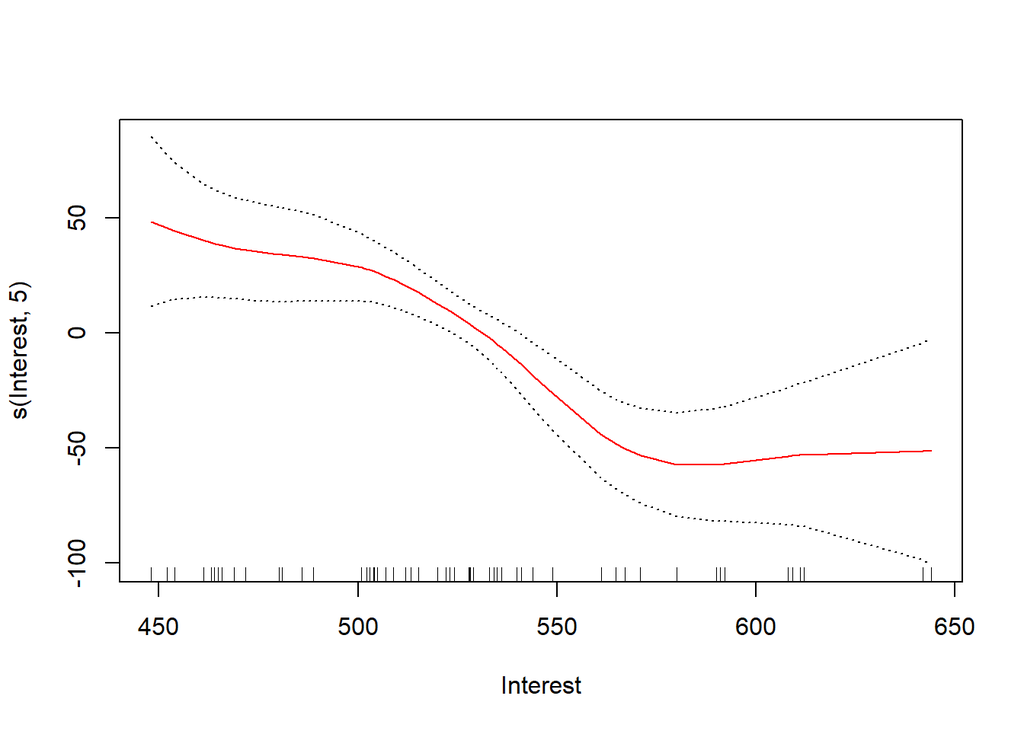

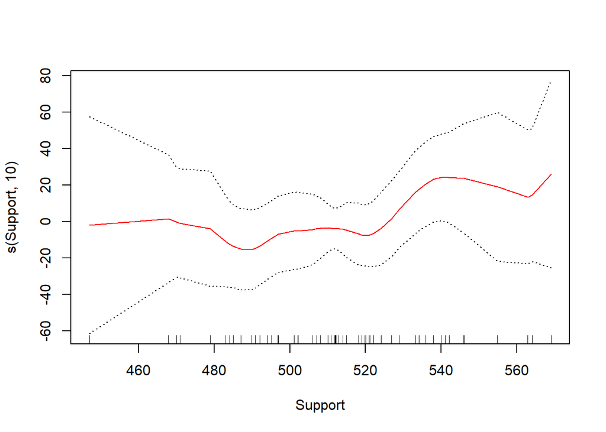

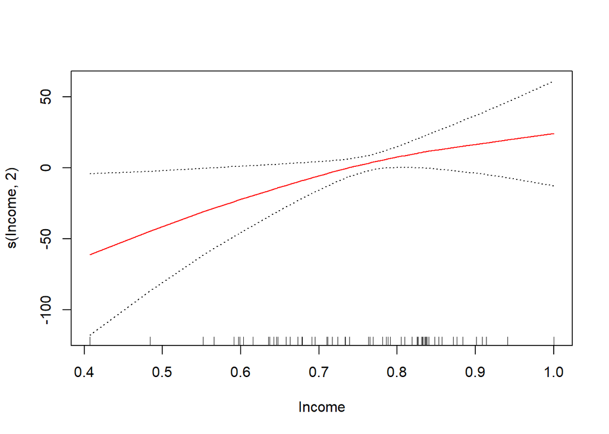

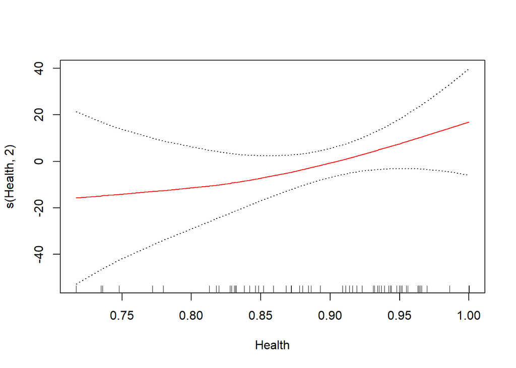

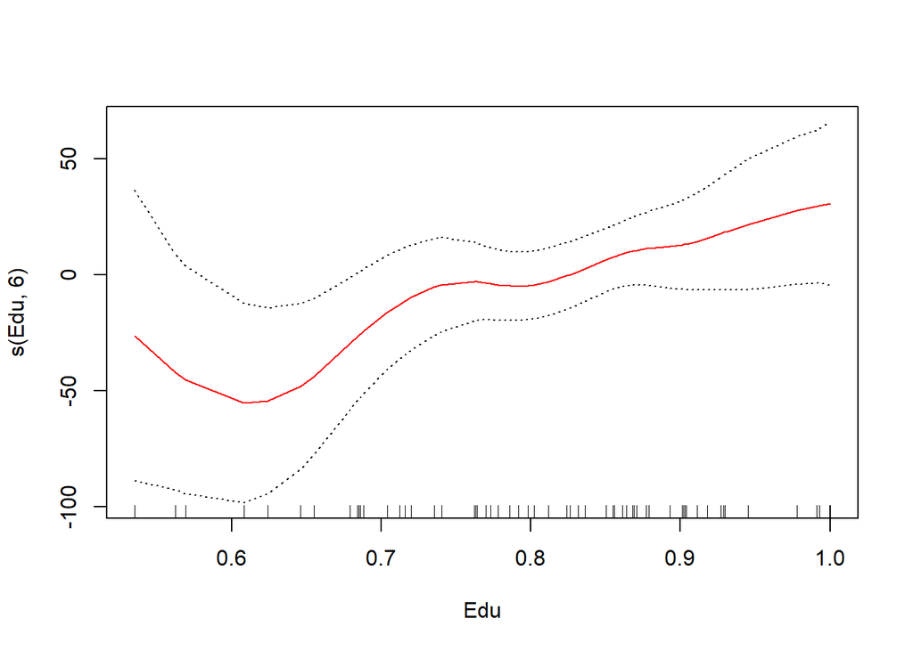

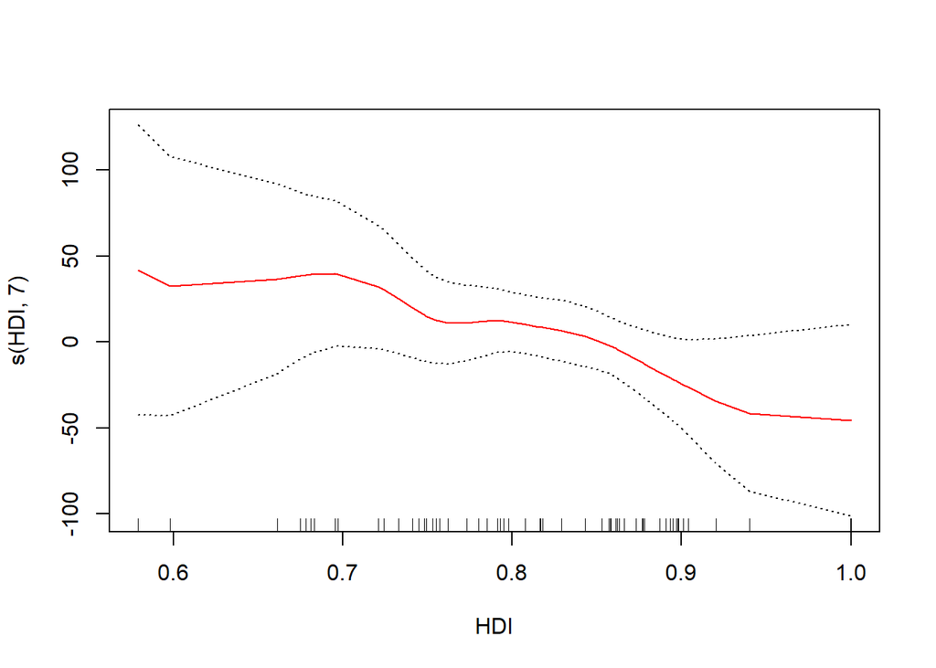

```r
modelo_gam <- gam (Overall ~  s(Interest,5) + s(Support,10) + s(Income,2) + s(Health,2) + s(Edu,6)
                   + s(HDI,7), data = PISA)


plot(modelo_gam, se = TRUE, col = "red")
```

```r
summary(modelo_gam)
```

```
##
## Call: gam(formula = Overall ~ s(Interest, 5) + s(Support, 10) + s(Income,
##     2) + s(Health, 2) + s(Edu, 6) + s(HDI, 7), data = PISA)
## Deviance Residuals:
##      Min       1Q   Median       3Q      Max
## -52.9938 -10.5459   0.2258  14.7964  49.4749
##
## (Dispersion Parameter for gaussian family taken to be 746.6137)
##
##     Null Deviance: 166829 on 64 degrees of freedom
## Residual Deviance: 23891.27 on 31.9995 degrees of freedom
## AIC: 636.4103
##
## Number of Local Scoring Iterations: NA
##
## Anova for Parametric Effects
##                Df Sum Sq Mean Sq  F value    Pr(>F)
## s(Interest, 5)  1 100715  100715 134.8963 5.159e-13 ***
## s(Support, 10)  1   3547    3547   4.7512  0.036749 *
## s(Income, 2)    1   5647    5647   7.5630  0.009719 **
## s(Health, 2)    1    655     655   0.8767  0.356130
## s(Edu, 6)       1    973     973   1.3033  0.262077
## s(HDI, 7)       1   2029    2029   2.7170  0.109072
## Residuals      32  23891     747
## ---
## Signif. codes:  0 '***' 0.001 '**' 0.01 '*' 0.05 '.' 0.1 ' ' 1
##
## Anova for Nonparametric Effects
##                Npar Df Npar F   Pr(F)
## (Intercept)
## s(Interest, 5)       4 3.4020 0.01992 *
## s(Support, 10)       9 0.7571 0.65534
## s(Income, 2)         1 2.2626 0.14234
## s(Health, 2)         1 0.6770 0.41672
## s(Edu, 6)            5 1.5176 0.21208
## s(HDI, 7)            6 0.9244 0.49071
## ---
## Signif. codes:  0 '***' 0.001 '**' 0.01 '*' 0.05 '.' 0.1 ' ' 1
```

Procedemos a construir dos modelos más, uno donde las variables con el p-valor del modelo 1, mantengan una relación lineal o utilizando local regression utilizaremos un span = 0.7

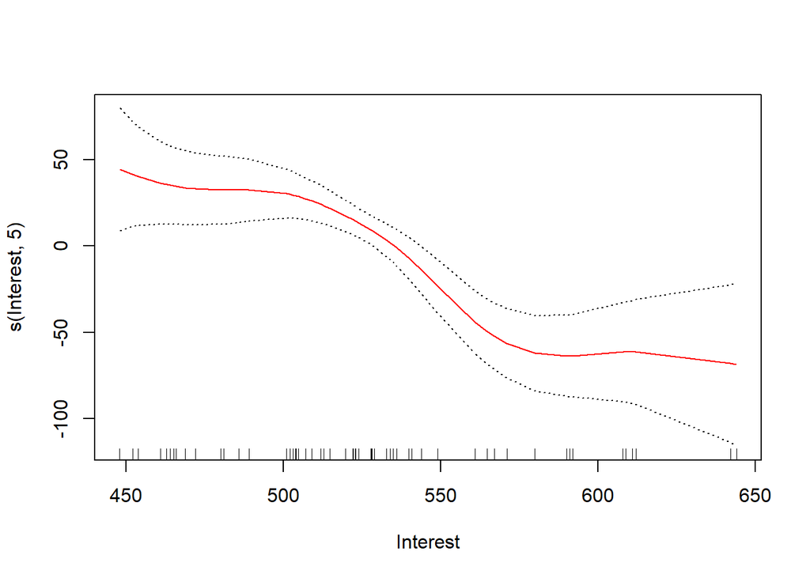

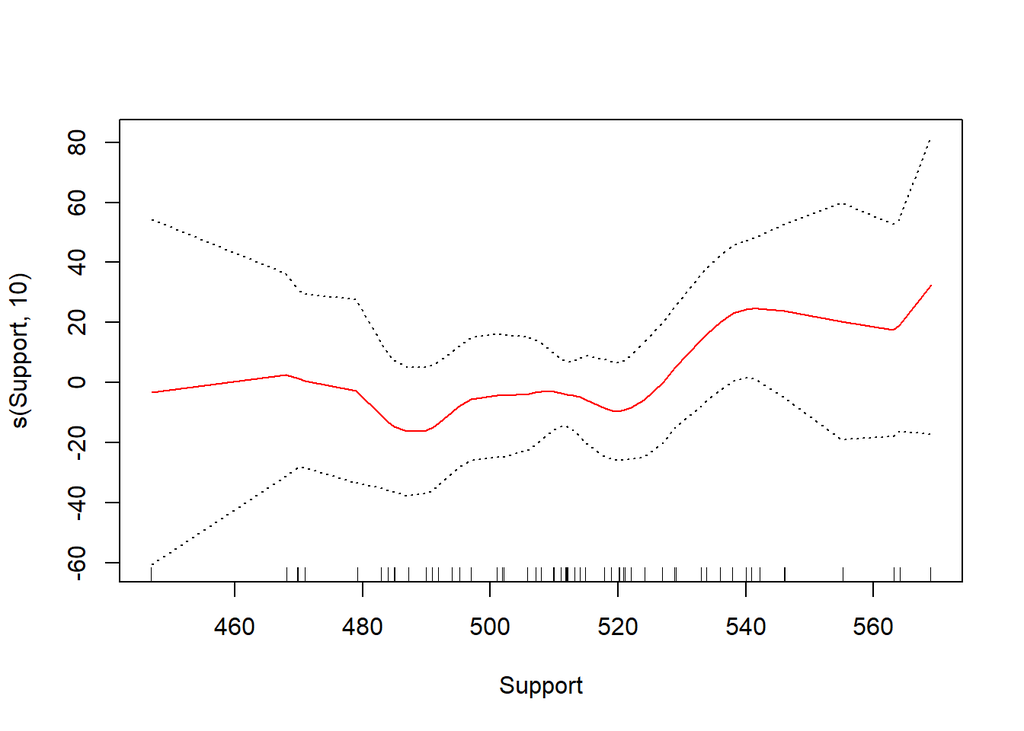

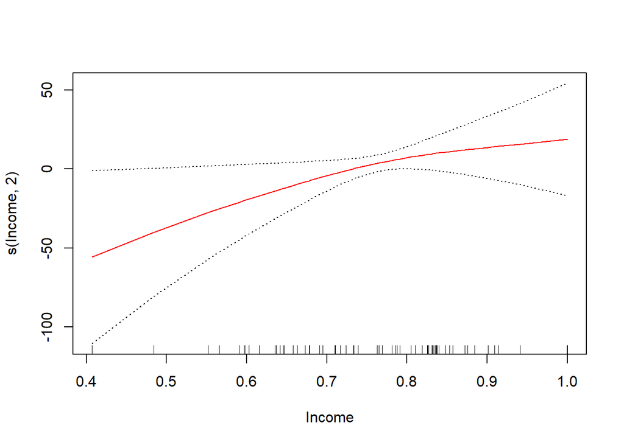

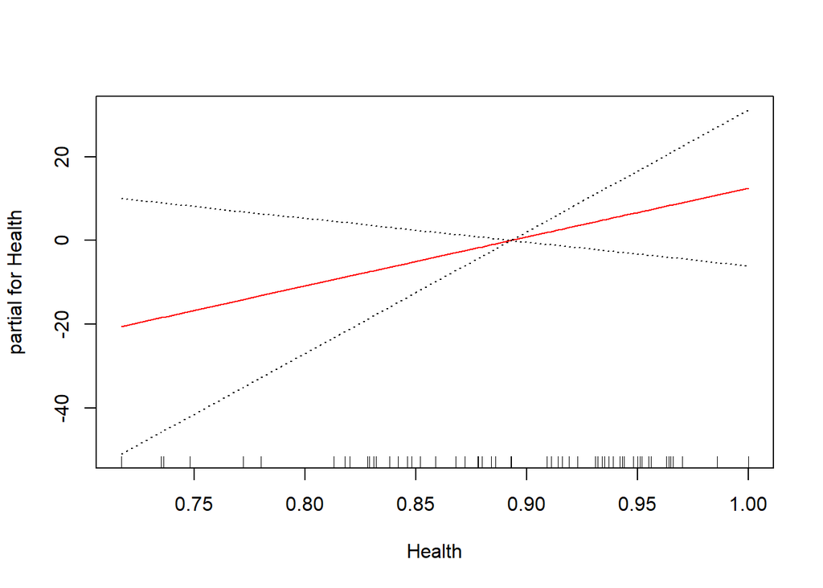

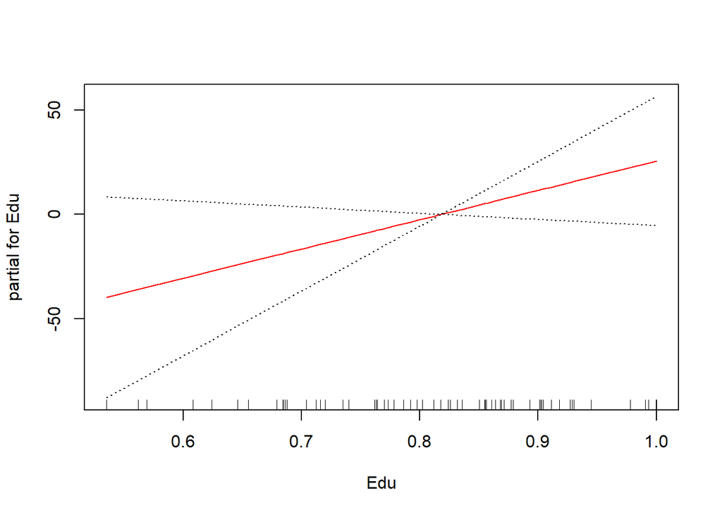

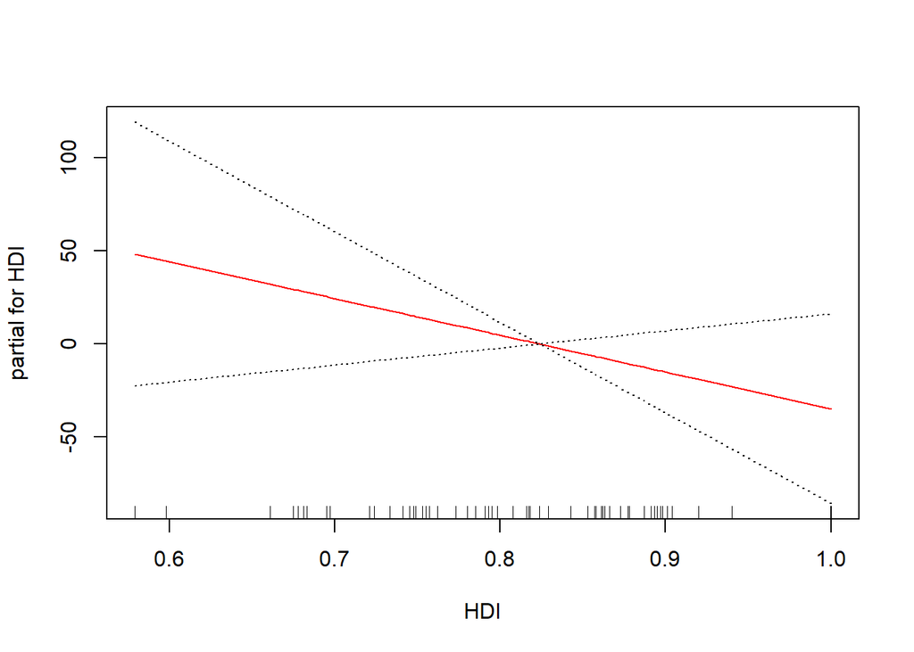

```r
modelo_gam2 <- gam (Overall ~  s(Interest,5) + s(Support,10) + s(Income,2) + Health + Edu
                   + HDI, data = PISA)

plot(modelo_gam2, se = TRUE, col = "red")
```

```r
summary(modelo_gam2)
```

```
##
## Call: gam(formula = Overall ~ s(Interest, 5) + s(Support, 10) + s(Income,
##     2) + Health + Edu + HDI, data = PISA)
## Deviance Residuals:
##      Min       1Q   Median       3Q      Max
## -59.7372 -12.6911   0.6746  12.1270  59.2659
##
## (Dispersion Parameter for gaussian family taken to be 695.2506)
##
##     Null Deviance: 166829 on 64 degrees of freedom
## Residual Deviance: 30590.97 on 43.9999 degrees of freedom
## AIC: 628.4769
##
## Number of Local Scoring Iterations: NA
##
## Anova for Parametric Effects
##                Df Sum Sq Mean Sq  F value    Pr(>F)
## s(Interest, 5)  1 103769  103769 149.2545 9.823e-16 ***
## s(Support, 10)  1   3647    3647   5.2458  0.026850 *
## s(Income, 2)    1   5181    5181   7.4516  0.009079 **
## Health          1    672     672   0.9669  0.330835
## Edu             1    637     637   0.9158  0.343807
## HDI             1   1296    1296   1.8646  0.179036
## Residuals      44  30591     695
## ---
## Signif. codes:  0 '***' 0.001 '**' 0.01 '*' 0.05 '.' 0.1 ' ' 1
##
## Anova for Nonparametric Effects
##                Npar Df Npar F    Pr(F)
## (Intercept)
## s(Interest, 5)       4 4.5707 0.003569 **
## s(Support, 10)       9 0.9565 0.487902
## s(Income, 2)         1 3.0266 0.088899 .
## Health
## Edu
## HDI
## ---
## Signif. codes:  0 '***' 0.001 '**' 0.01 '*' 0.05 '.' 0.1 ' ' 1
```

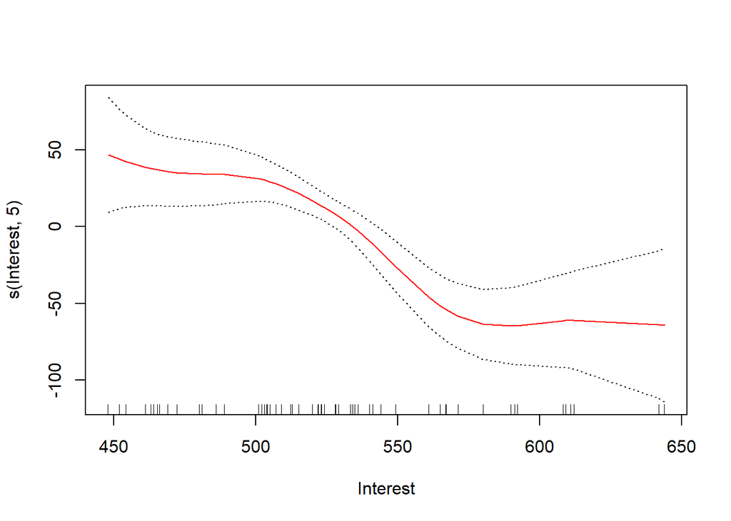

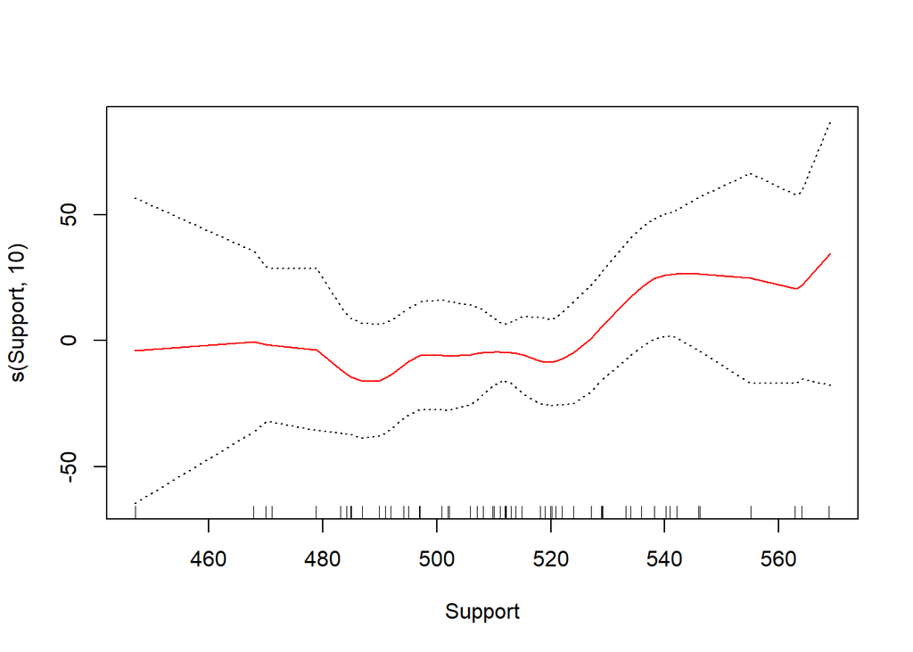

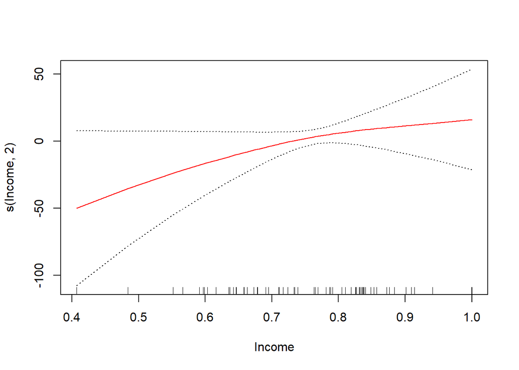

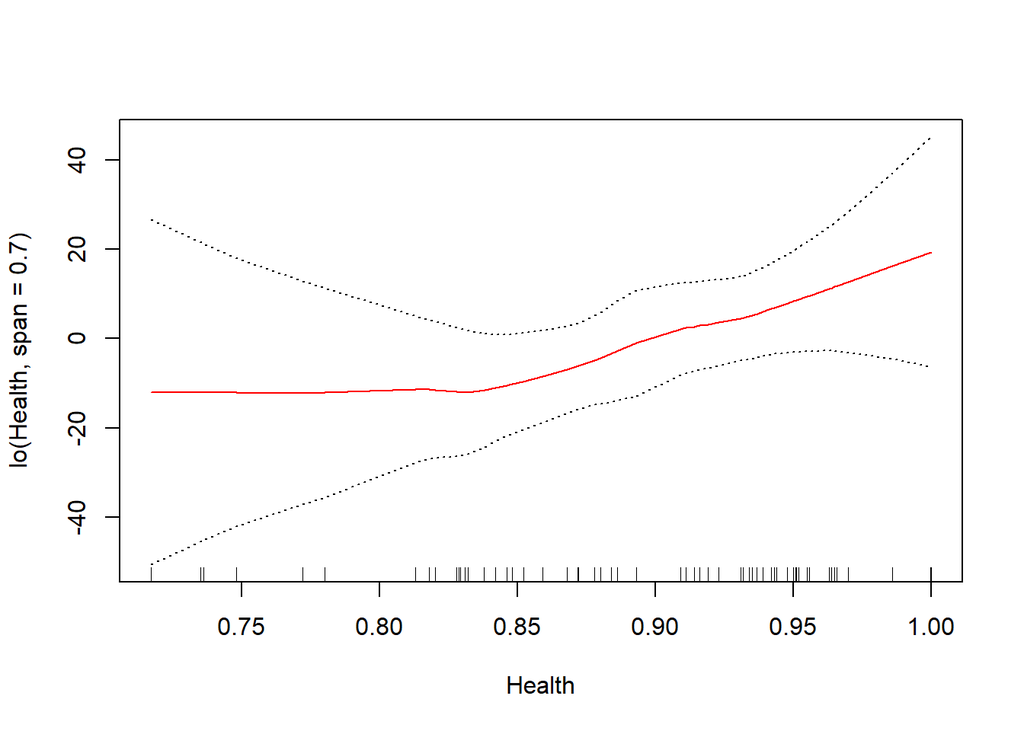

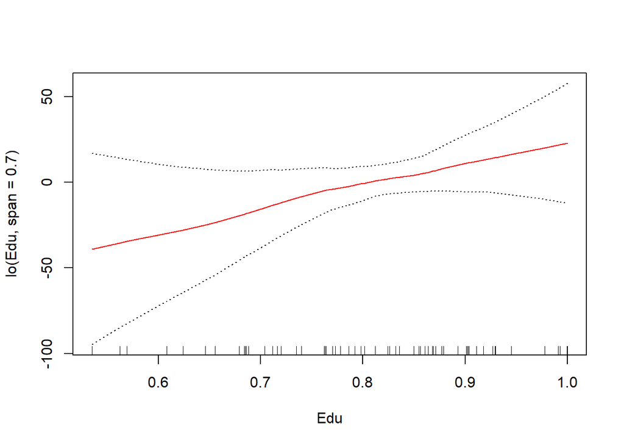

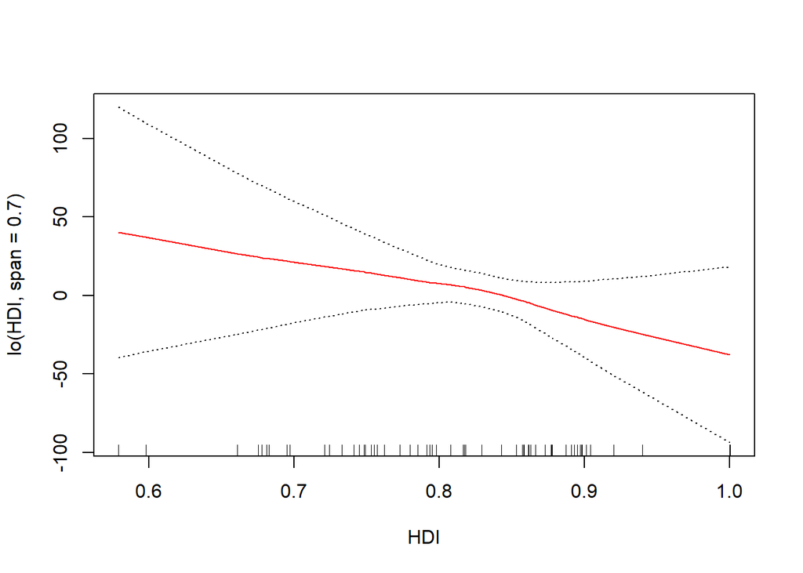

```r
modelo_gam3 <- gam (Overall ~  s(Interest,5) + s(Support,10) + s(Income,2) + lo(Health,span = 0.7) + lo(Edu, span = 0.7)
                    + lo(HDI, span = 0.7), data = PISA)

plot(modelo_gam3, se = TRUE, col = "red")
```

```r
summary(modelo_gam3)
```

```
##
## Call: gam(formula = Overall ~ s(Interest, 5) + s(Support, 10) + s(Income,
##     2) + lo(Health, span = 0.7) + lo(Edu, span = 0.7) + lo(HDI,
##     span = 0.7), data = PISA)
## Deviance Residuals:
##     Min      1Q  Median      3Q     Max
## -60.110 -11.686   1.863  13.589  52.822
##
## (Dispersion Parameter for gaussian family taken to be 774.2872)
##
##     Null Deviance: 166829 on 64 degrees of freedom
## Residual Deviance: 29495.75 on 38.0941 degrees of freedom
## AIC: 637.9188
##
## Number of Local Scoring Iterations: 1
##
## Anova for Parametric Effects
##                            Df Sum Sq Mean Sq  F value    Pr(>F)
## s(Interest, 5)          1.000  98184   98184 126.8057 1.101e-13 ***
## s(Support, 10)          1.000   4183    4183   5.4028   0.02553 *
## s(Income, 2)            1.000   4574    4574   5.9070   0.01990 *
## lo(Health, span = 0.7)  1.000   1031    1031   1.3316   0.25571
## lo(Edu, span = 0.7)     1.000    517     517   0.6677   0.41892
## lo(HDI, span = 0.7)     1.000   1171    1171   1.5129   0.22624
## Residuals              38.094  29496     774
## ---
## Signif. codes:  0 '***' 0.001 '**' 0.01 '*' 0.05 '.' 0.1 ' ' 1
##
## Anova for Nonparametric Effects
##                        Npar Df Npar F    Pr(F)
## (Intercept)
## s(Interest, 5)             4.0 4.2579 0.006041 **
## s(Support, 10)             9.0 0.8595 0.568234
## s(Income, 2)               1.0 2.3643 0.132414
## lo(Health, span = 0.7)     1.9 0.6449 0.519792
## lo(Edu, span = 0.7)        1.9 0.1574 0.845379
## lo(HDI, span = 0.7)        2.1 0.3559 0.716450
## ---
## Signif. codes:  0 '***' 0.001 '**' 0.01 '*' 0.05 '.' 0.1 ' ' 1
```

### ANOVA

Procedemos a realizar una comparación de los modelos medieante ANOVA.

```r
anova(modelo_gam,modelo_gam2,modelo_gam3, test = 'F')
```

```
## Analysis of Deviance Table
##
## Model 1: Overall ~ s(Interest, 5) + s(Support, 10) + s(Income, 2) + s(Health,
##     2) + s(Edu, 6) + s(HDI, 7)
## Model 2: Overall ~ s(Interest, 5) + s(Support, 10) + s(Income, 2) + Health +
##     Edu + HDI
## Model 3: Overall ~ s(Interest, 5) + s(Support, 10) + s(Income, 2) + lo(Health,
##     span = 0.7) + lo(Edu, span = 0.7) + lo(HDI, span = 0.7)
##   Resid. Df Resid. Dev       Df Deviance      F Pr(>F)
## 1    32.000      23891
## 2    44.000      30591 -12.0004  -6699.7 0.7478 0.6960
## 3    38.094      29496   5.9058   1095.2 0.2484 0.9549
```

Concluimos que el modelo 2 es el mejor.